# Peer Assessment 1

### Loading and preprocessing the data

1. Load data
2. Remove missing data

```r
setwd("C:/Users/jeffthatcher/Cloud Drive/RRepos/Reproducible_Research/RepData_PeerAssessment1")

activityDataFull <- read.table("C:/Users/jeffthatcher/Cloud Drive/RRepos/repdata-data-activity/activity.csv", sep = ",", header = TRUE)

activityData <- na.omit(activityDataFull)
```

### Mean total number of steps taken per day

1. Mean total number of steps taken per day
2. Histogram of total steps per day
3. Mean and median of the total number of steps taken per day

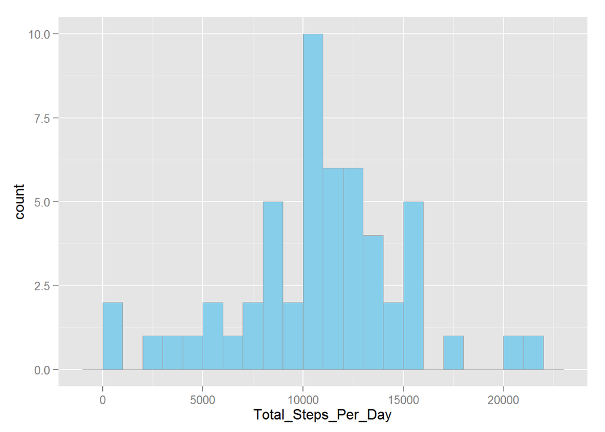

```r
meanDailySteps <- as.data.frame(as.matrix(tapply(activityData$steps, activityData$date, sum)))

colnames(meanDailySteps) <- c("Total_Steps_Per_Day")

library(ggplot2)
ggplot(meanDailySteps, aes(x=Total_Steps_Per_Day)) + geom_histogram(binwidth = 1000, fill = "sky blue", colour = "grey60", size=0.2)
```

```r
meanSteps <- mean(na.omit(meanDailySteps$steps))
medianSteps <- median(na.omit(meanDailySteps$steps))
```

[output not shown]

### The average daily activity pattern

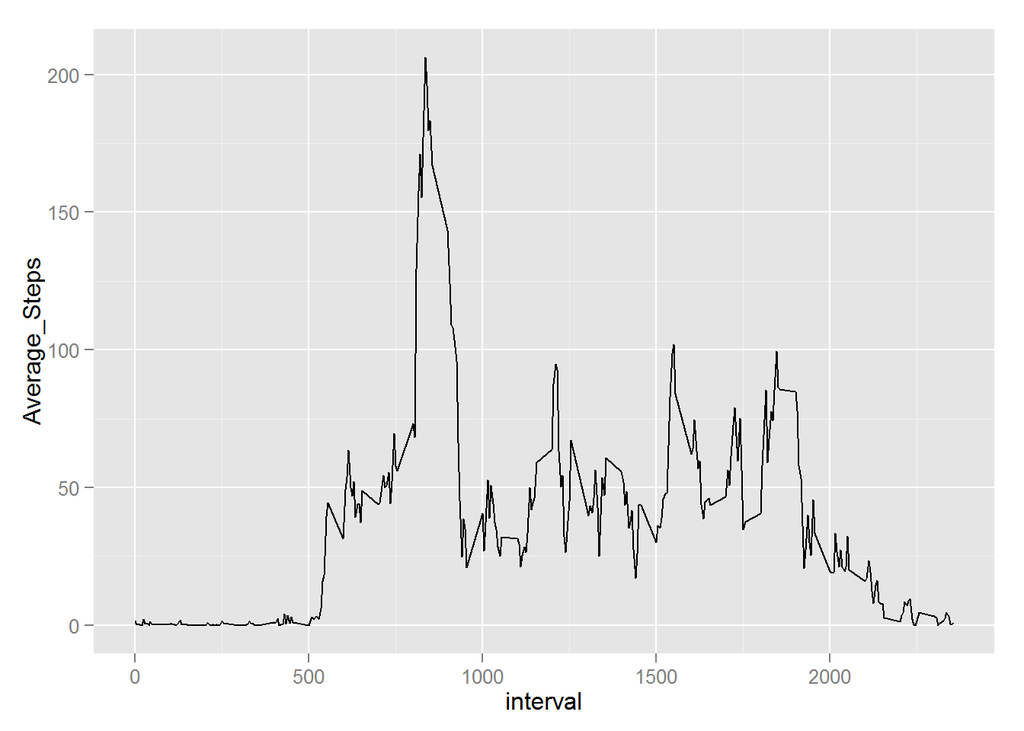

```r
intervalSteps <- aggregate(activityData$steps, list(activityData$interval), mean)

colnames(intervalSteps) <- c("interval", "Average_Steps")

ggplot(intervalSteps, aes(interval, Average_Steps)) + geom_line()
```

```r
mostSteps <- intervalSteps[which.max(intervalSteps$steps), ]
```

### Imputing missing values

1. Calculate and report the total number of missing values in the dataset (i.e. the total number of rows with NAs)

```r
missingNAN<- is.na(activityDataFull$steps)
totalMissing <- sum(as.numeric(missingNAN))
```

The total number of missing values is **2304**

2. Devise a strategy for filling in all of the missing values in the dataset. The strategy does not need to be sophisticated. For example, you could use the mean/median for that day, or the mean for that 5-minute interval, etc.

*I used the mean for that 5-minute interval as the strategy to fill the missing values*

3. Create a new dataset that is equal to the original dataset but with the missing data filled in.

```r
for (i in 1:length(activityDataFull$steps)){
        if (is.na(activityDataFull$steps[i] == TRUE)){
        activityDataFull$steps[i] <- intervalSteps$Average_Steps[match(activityDataFull$interval[i], intervalSteps$interval)]
        }
}
```

4. Make a histogram of the total number of steps taken each day and Calculate and report the mean and median total number of steps taken per day.

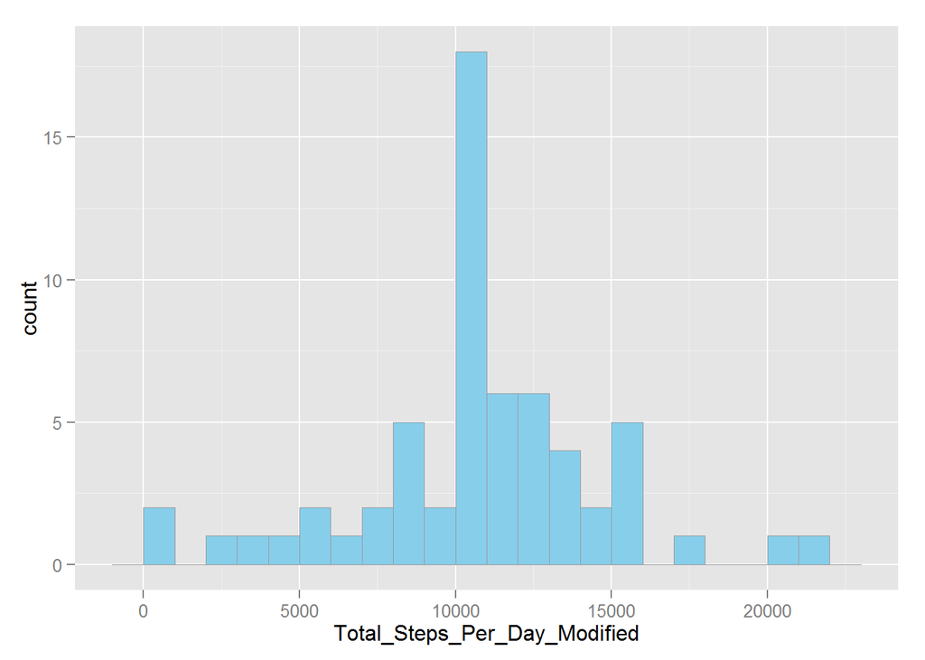

```r
meanDailyStepsFull <- as.data.frame(as.matrix(tapply(activityDataFull$steps, activityDataFull$date, sum)))

colnames(meanDailyStepsFull) <- c("Total_Steps_Per_Day_Modified")

ggplot(meanDailyStepsFull, aes(x=Total_Steps_Per_Day_Modified)) + geom_histogram(binwidth = 1000, fill = "sky blue", colour = "grey60", size=0.2)
```

```r
meanStepsFull <- mean(meanDailyStepsFull$steps_Modified)
medianStepsFull <- median(meanDailyStepsFull$steps_Modified)
```

[output not shown]

Do these values differ from the estimates from the first part of the assignment? What is the impact of imputing missing data on the estimates of the total daily number of steps?

*By plotting the initial histogram and the histogram where the missing data was filled-in, we can see the difference achieved by replacing the missing data. The only noticable change is an increase in the number of days where 10,000 - 11,000 steps occurred. Otherwise, the two histograms are identical.*

```r
DF <- merge(meanDailySteps, meanDailyStepsFull)
library(reshape2)
DF <- melt(DF)
```

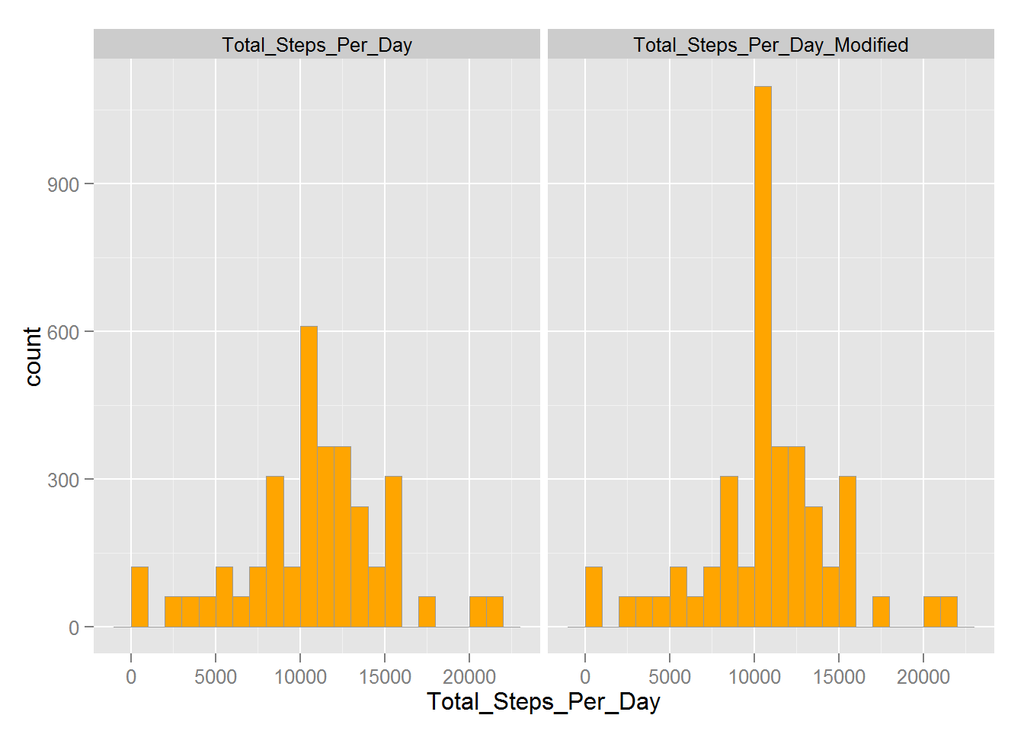

```r
colnames(DF) <- c("variable", "Total_Steps_Per_Day")

ggplot(DF, aes(x=Total_Steps_Per_Day)) + geom_histogram(binwidth = 1000, fill = "orange", colour = "grey60", size=0.2) + facet_grid(.~ variable)
```

### Are there differences in activity patterns between weekdays and weekends?

1. Create a new factor variable in the dataset with two levels - “weekday” and “weekend” indicating whether a given date is a weekday or weekend day.
2. Make a panel plot containing a time series plot (i.e. type = “l”) of the 5-minute interval (x-axis) and the average number of steps taken, averaged across all weekday days or weekend days (y-axis).

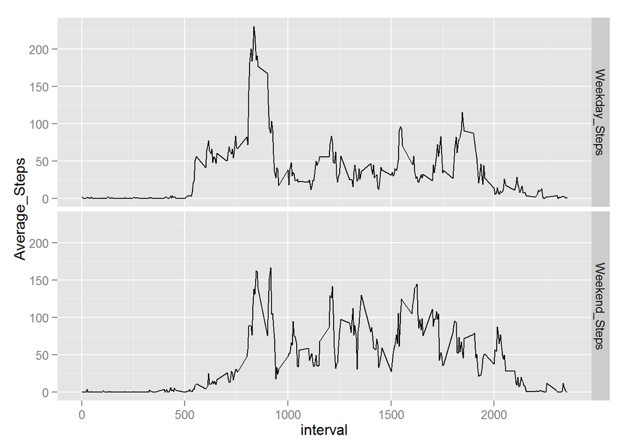

```r
#add the day-of-week column
activityDataFull$day <- weekdays(as.Date(activityDataFull$date), abbreviate=FALSE)

#convert day-of-week column vales to Weekday or Weekend
for (i in 1:length(activityDataFull$day)){
if (activityDataFull$day[i] == "Saturday" || activityDataFull$day[i] == "Sunday"){
        activityDataFull$day[i] <- "Weekend"
} else {
        activityDataFull$day[i] <- "Weekday"
}
}

# calculate the average interval steps for weekend and weekdays separetely and then combine.
activityDataWeekend <- subset(activityDataFull, day == "Weekend")

activityDataWeekday <- subset(activityDataFull, day == "Weekday")

activityIntervalStepsWeekend <- aggregate(activityDataWeekend$steps, list(activityDataWeekend$interval), mean)
colnames(activityIntervalStepsWeekend) <- c("interval", "Weekend_Steps")

activityIntervalStepsWeekday <- aggregate(activityDataWeekday$steps, list(activityDataWeekday$interval), mean)
colnames(activityIntervalStepsWeekday) <- c("interval", "Weekday_Steps")

DF2 <- merge(activityIntervalStepsWeekday, activityIntervalStepsWeekend)
DF2 <- melt(DF2, id = "interval")

# plot
colnames(DF2) <- c("interval", "variable", "Average_Steps")
ggplot(DF2, aes(interval,  Average_Steps)) + geom_line() + facet_grid(variable ~ .)
```